# chapter3.Rmd

Ahi

19 marraskuuta 2017

# Exercise 3. Logistic Regression

In this exercise, I am going to perform logistic regressoin to see the effect of different variabes on students’ alcohol consumption. I have combined Math-Por dataset and called alc, which includes data from students in both mathematics and Portugies classes. First, let us run some of the libraries we need.

```r
library(tidyr)

library(dplyr)
```

```r
library(ggplot2)

library(magrittr)
```

# 2. Reading the joined dataset

```r
alc <- read.table("C:/Data/IODS-project/alc.csv", sep=",", header=TRUE)
```

This is a dataset which contains information on students achievment in two classes, math and Portuguese language. The aim is to see, e.g., how alocohol consumtpion and gender affect students’ performance. The name of the variables in the dataset can be seen here:

```r
colnames(alc)
```

```
##  [1] "X"          "school"     "sex"        "age"        "address"
##  [6] "famsize"    "Pstatus"    "Medu"       "Fedu"       "Mjob"
## [11] "Fjob"       "reason"     "nursery"    "internet"   "guardian"
## [16] "traveltime" "studytime"  "failures"   "schoolsup"  "famsup"
## [21] "paid"       "activities" "higher"     "romantic"   "famrel"
## [26] "freetime"   "goout"      "Dalc"       "Walc"       "health"
## [31] "absences"   "G1"         "G2"         "G3"         "alc_use"
## [36] "high_use"
```

# 3. The hypotheses regarding four variables and alc consumption

In this exercise, I am interested in studying the effect of students’ gender, age, health, and final grade (G3) on students alcohol consumption. Since the dependent variable is categorical (high vs. low consumption), logistic regression analysis is used. The following are my hypotheses:

H1. Male studnets are more likely to consume high amount of alcohol compared with their female classmates

H2. There is a positive relationship between age and alcohol consumption. As such, the older the students the higher the likelihood of high alcohol consumption.

H3. There is a negative relationship between students’ health and high alcohol consumption.

H4. There is a negative relationship between students’ grades and high alcohol consumption.

# 4. exploring the distribution of the variables

Let’s look at the disribution of the variables selected:

```r
alc %>% group_by(sex, high_use) %>% summarise(count = n(), mean_grade = mean(G3))
```

```
## # A tibble: 4 x 4
## # Groups:   sex [?]
##      sex high_use count mean_grade
##   <fctr>    <lgl> <int>      <dbl>
## 1      F    FALSE   156   11.39744
## 2      F     TRUE    42   11.71429
## 3      M    FALSE   112   12.20536
## 4      M     TRUE    72   10.27778
```

Now let’s look at some boxplot of the variables

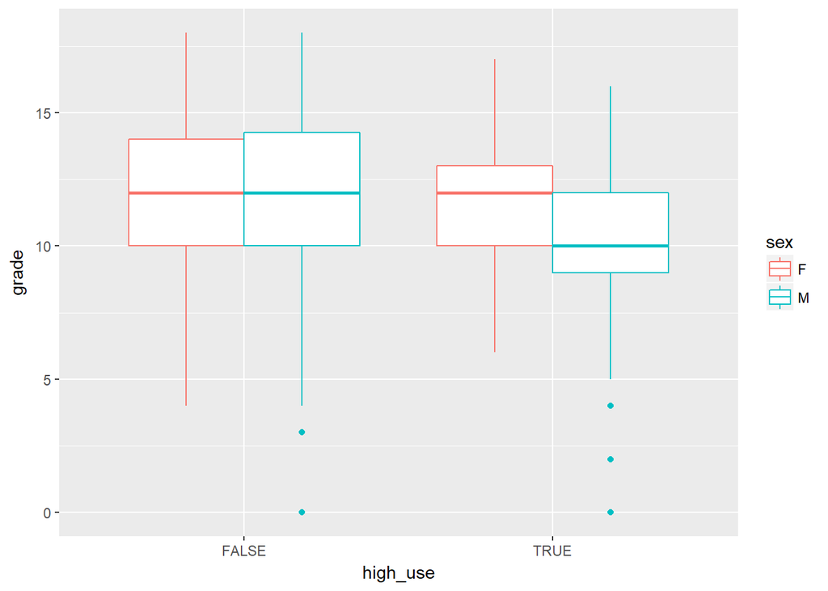

```r
g1 <- ggplot(alc, aes(x = high_use, y = G3, col = sex))


g1 + geom_boxplot() + ylab("grade")
```

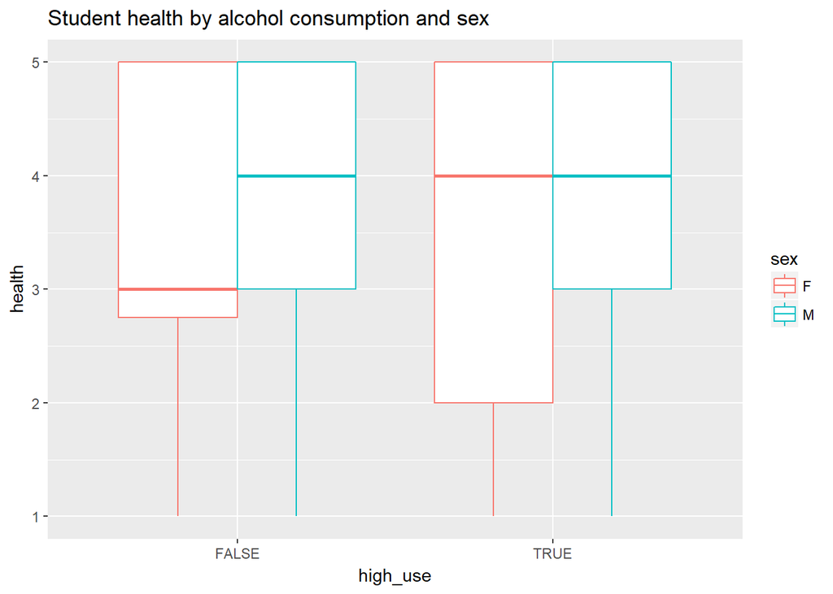

```r
g2 <- ggplot(alc, aes(x = high_use, y = health, col = sex)) + ggtitle("Student health by alcohol consumption and sex")

g2 + geom_boxplot() + ylab("health")
```

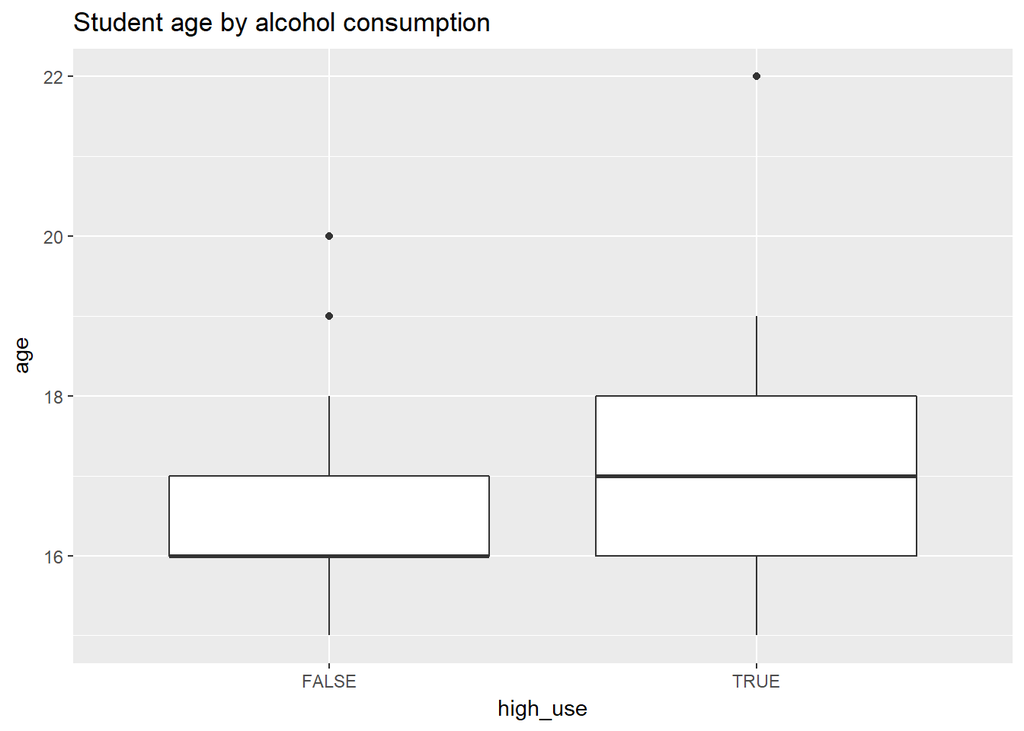

```r
g3 <- ggplot(alc, aes(x = high_use, y = age)) + ggtitle("Student age by alcohol consumption")

g3 + geom_boxplot() + ylab("age")
```

# 5. Logistic regression

looking at the logistic model, where alcohol consumption is the depedent variables, which is binory (0 and 1), and gender, health, age, and grade are independent variables.

```r
m <- glm(high_use ~ sex + G3 + health + age, data = alc, family = "binomial")
```

printing out the model:

```r
m
```

```
##
## Call:  glm(formula = high_use ~ sex + G3 + health + age, family = "binomial",
##     data = alc)
##
## Coefficients:
## (Intercept)         sexM           G3       health          age
##    -3.78271      0.87393     -0.07177      0.05017      0.18628
##
## Degrees of Freedom: 381 Total (i.e. Null);  377 Residual
## Null Deviance:       465.7
## Residual Deviance: 440.9     AIC: 450.9
```

coefficients and the summary of the model

```r
coef(m)
```

```
## (Intercept)        sexM          G3      health         age
## -3.78270813  0.87393096 -0.07177345  0.05016889  0.18627672
```

```r
summary(m)
```

```
##
## Call:
## glm(formula = high_use ~ sex + G3 + health + age, family = "binomial",
##     data = alc)
##
## Deviance Residuals:
##     Min       1Q   Median       3Q      Max
## -1.5671  -0.8564  -0.6731   1.2261   2.0567
##
## Coefficients:
##             Estimate Std. Error z value Pr(>|z|)
## (Intercept) -3.78271    1.86027  -2.033 0.042011 *
## sexM         0.87393    0.23551   3.711 0.000207 ***
## G3          -0.07177    0.03560  -2.016 0.043810 *
## health       0.05017    0.08613   0.583 0.560228
## age          0.18628    0.10005   1.862 0.062639 .
## ---
## Signif. codes:  0 '***' 0.001 '**' 0.01 '*' 0.05 '.' 0.1 ' ' 1
##
## (Dispersion parameter for binomial family taken to be 1)
##
##     Null deviance: 465.68  on 381  degrees of freedom
## Residual deviance: 440.87  on 377  degrees of freedom
## AIC: 450.87
##
## Number of Fisher Scoring iterations: 4
```

Now, let us Compute odds ratios (OR)

```r
OR <- coef(m) %>% exp
```

computing confidence intervals (CI)

```r
CI <- confint(m) %>% exp
```

Printing out the odds ratios with their confidence intervals

```r
cbind(OR, CI)
```

```
##                     OR        2.5 %    97.5 %
## (Intercept) 0.02276097 0.0005652066 0.8480239
## sexM        2.39631217 1.5169185615 3.8248624
## G3          0.93074173 0.8672495153 0.9975278
## health      1.05144866 0.8892957060 1.2474625
## age         1.20475559 0.9914394848 1.4692182
```

As can be seen from the results, the gender has the widest confidence interval.

Hypotheses test results:

The results reveal that gender is a significant variable. According to this and the distribution of this variable, shown earlier, male studnets are more likely to drink high amount of alcohol. This confirms my 1st hypothesis.

There is no relationship between students’ health and high alcohol consumption, rejecting the 3rd hypothesis. This is could be due to the fact that students are very younge, hence alcoholc consumption does not affect their health yet.

There is a negative, significant relationship between students’ grade and high alcohol consumption, confirming the 4th hypothesis.

# 6. Exploring the predictive power of the model

```r
m2 <- glm(high_use ~ sex + G3 + age, data = alc, family = "binomial")
```

looking at the predictive power of m2

```r
probabilities <- predict(m2, type = "response")
```

adding the predicted probabilities to ‘alc’

```r
alc <- mutate(alc, probability = probabilities)
```

using the probabilities to make a prediction of high_use

```r
alc <- mutate(alc, prediction = probability > 0.5)
```

Looking at the last ten original classes, predicted probabilities, and class predictions

```r
select(alc, sex, G3, age, high_use, probability, prediction) %>% tail(10)
```

```
##     sex G3 age high_use probability prediction
## 373   M  0  19    FALSE   0.6972126       TRUE
## 374   M  2  18     TRUE   0.6236442       TRUE
## 375   F 12  18    FALSE   0.2445347      FALSE
## 376   F  8  18    FALSE   0.3033281      FALSE
## 377   F  5  19    FALSE   0.3945166      FALSE
## 378   F 12  18    FALSE   0.2445347      FALSE
## 379   F  4  18    FALSE   0.3693463      FALSE
## 380   F  4  18    FALSE   0.3693463      FALSE
## 381   M 13  17     TRUE   0.3796480      FALSE
## 382   M 10  18     TRUE   0.4780369      FALSE
```

tabulating the target variable versus the predictions

```r
table(high_use = alc$high_use, prediction = alc$prediction)
```

```
##         prediction
## high_use FALSE TRUE
##    FALSE   260    8
##    TRUE    102   12
```

displaying the actual values and the predictions

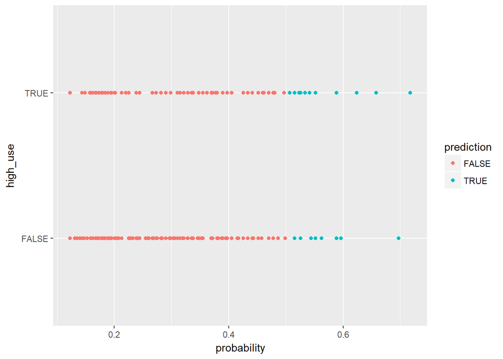

```r
g <- ggplot(alc, aes(x = probability, y = high_use, col = prediction))

g + geom_point()
```

Computing the total proportion of inaccurately classified individuals

```r
loss_func <- function(class, prob) {
  n_wrong <- abs(class - prob) > 0.5
  mean(n_wrong)
}

loss_func(class = alc$high_use, prob = alc$probability)
```

```
## [1] 0.2879581
```

# 7 and 8. Performing cross-validation to compare different models

```r
library(boot)
cv <- cv.glm(data = alc, cost = loss_func, glmfit = m, K = 10)
cv$delta[1]
```

```
## [1] 0.2905759
```

After performing this 10-fold crosss-validation test, we can see that the prediction error is larger than the model in the DataCamp (~ 0.28 > 0.26). Therefore, it seems that this model does not perform better. So, let’s remove the variable “age”, and keep only the “sex” and “G3”, which are more significant statistically. Let’s call the model, m3:

```r
m3 <- glm(high_use ~ sex + G3, data = alc, family = "binomial")
```

Now, let’s look at the prediction error of m3:

```r
cv <- cv.glm(data = alc, cost = loss_func, glmfit = m3, K = 10)
cv$delta[1]
```

```
## [1] 0.3010471
```

Still the prediction error is large. So, let’s introduce new variables to the model: absences and sex, and remove G3.

```r
m4 <- glm(high_use ~ sex + absences, data = alc, family = "binomial")

cv <- cv.glm(data = alc, cost = loss_func, glmfit = m4, K = 10)
cv$delta[1]
```

```
## [1] 0.2617801
```

As can be seen, now the predictive error of the model is smaller than the previous models. It is however the same as the one in the DataCamp exercise.

So, let’s modify our hypotheses and develop a new logistic regression model - with different variables - to test whether or ot our model improves. Accordingly, in the follwing, I introduce explanatory variables to the model, while keeping the dependent variables (high_use) the same. I start with a large number of variables and continue with smaller number.

m5 - explanatory variables: sex, age, studytime, failures, famsup, goout (going out with friends), famrel (quality of family relationship), health, and absences.

```r
m5 <- glm(high_use ~ sex + age + studytime + failures + famsup + goout + famrel + health + absences, data = alc, family = "binomial")
```

Now, let’s look at a summary of the model as well as the coefficients.

```r
summary(m5)
```

```
##
## Call:
## glm(formula = high_use ~ sex + age + studytime + failures + famsup +
##     goout + famrel + health + absences, family = "binomial",
##     data = alc)
##
## Deviance Residuals:
##     Min       1Q   Median       3Q      Max
## -1.8993  -0.7472  -0.4766   0.7235   2.6787
##
## Coefficients:
##             Estimate Std. Error z value Pr(>|z|)
## (Intercept) -4.01069    2.04454  -1.962 0.049802 *
## sexM         0.80299    0.27398   2.931 0.003381 **
## age          0.10516    0.11619   0.905 0.365403
## studytime   -0.38004    0.17897  -2.124 0.033712 *
## failures     0.12425    0.22065   0.563 0.573353
## famsupyes    0.02573    0.27122   0.095 0.924417
## goout        0.75279    0.12531   6.008 1.88e-09 ***
## famrel      -0.40344    0.14372  -2.807 0.004999 **
## health       0.11984    0.09691   1.237 0.216238
## absences     0.07304    0.02201   3.318 0.000905 ***
## ---
## Signif. codes:  0 '***' 0.001 '**' 0.01 '*' 0.05 '.' 0.1 ' ' 1
##
## (Dispersion parameter for binomial family taken to be 1)
##
##     Null deviance: 465.68  on 381  degrees of freedom
## Residual deviance: 370.92  on 372  degrees of freedom
## AIC: 390.92
##
## Number of Fisher Scoring iterations: 4
```

```r
coef(m5)
```

```
## (Intercept)        sexM         age   studytime    failures   famsupyes
## -4.01069222  0.80299478  0.10516426 -0.38004369  0.12425443  0.02573115
##       goout      famrel      health    absences
##  0.75278867 -0.40344292  0.11984299  0.07303669
```

Let us now look at the predictive power of the model, by estimating the prediction error:

```r
cv <- cv.glm(data = alc, cost = loss_func, glmfit = m5, K = 10)
cv$delta[1]
```

```
## [1] 0.2251309
```

As the model summary reveals, the variables, sex, studytime, goout, famrel, and absences have statistically significant relationship with alocohol consumption (high_use). Also, the prediction error of the model now is smaller than previous models. It is also smaller than the model in the DataCamp. Therefore, this is a better model in general.

Now let us look at the boxplot of some of the variables in the model:

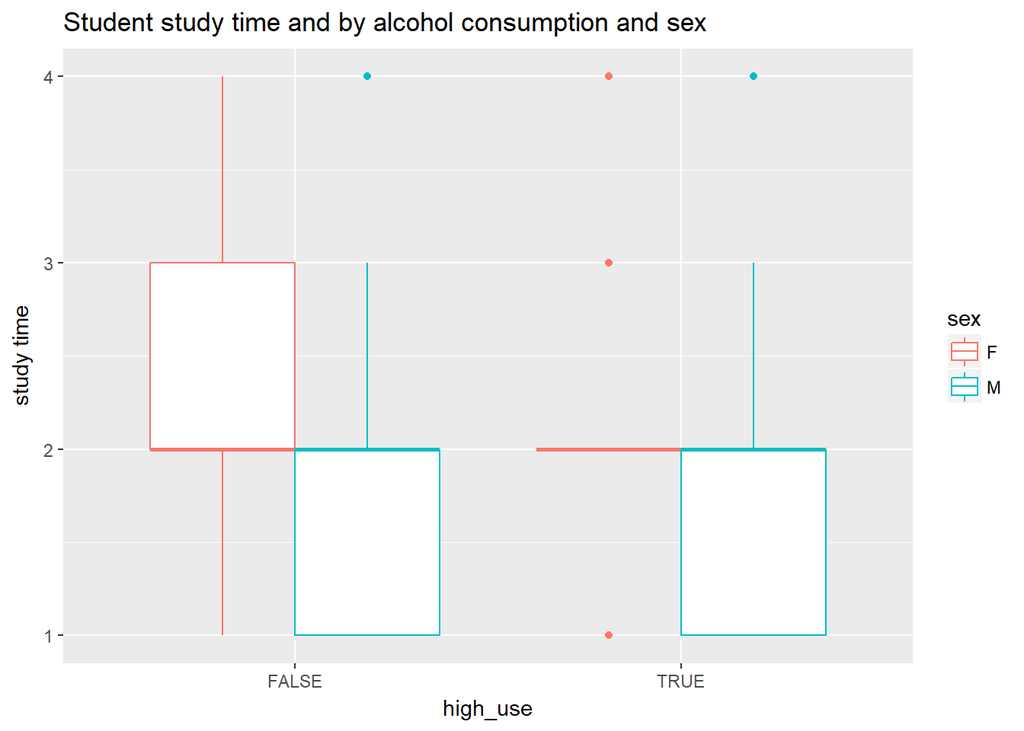

```r
g5 <- ggplot(alc, aes(x = high_use, y = studytime, col = sex)) + ggtitle("Student study time and by alcohol consumption and sex")

g5 + geom_boxplot() + ylab("study time")
```

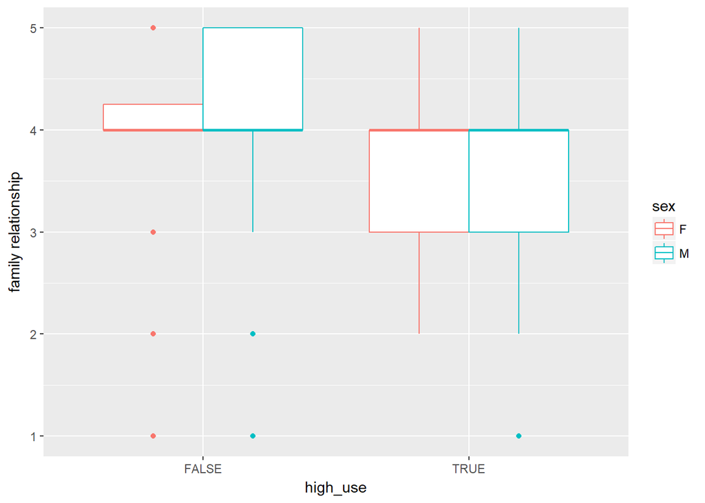

```r
g6 <- ggplot(alc, aes(x = high_use, y = famrel, col = sex))

g6 + geom_boxplot() + ylab("family relationship")
```

```r
m6 <- glm(high_use ~ sex + studytime + goout + famrel + absences, data = alc, family = "binomial")

summary(m6)
```

```
##
## Call:
## glm(formula = high_use ~ sex + studytime + goout + famrel + absences,
##     family = "binomial", data = alc)
##
## Deviance Residuals:
##     Min       1Q   Median       3Q      Max
## -1.7526  -0.7780  -0.4612   0.7265   2.6527
##
## Coefficients:
##             Estimate Std. Error z value Pr(>|z|)
## (Intercept) -1.89648    0.75069  -2.526 0.011526 *
## sexM         0.84545    0.26941   3.138 0.001700 **
## studytime   -0.40578    0.17223  -2.356 0.018471 *
## goout        0.76217    0.12333   6.180 6.41e-10 ***
## famrel      -0.37891    0.14038  -2.699 0.006950 **
## absences     0.07581    0.02213   3.425 0.000615 ***
## ---
## Signif. codes:  0 '***' 0.001 '**' 0.01 '*' 0.05 '.' 0.1 ' ' 1
##
## (Dispersion parameter for binomial family taken to be 1)
##
##     Null deviance: 465.68  on 381  degrees of freedom
## Residual deviance: 373.98  on 376  degrees of freedom
## AIC: 385.98
##
## Number of Fisher Scoring iterations: 4
```

```r
coef(m6)
```

```
## (Intercept)        sexM   studytime       goout      famrel    absences
## -1.89648456  0.84544998 -0.40577857  0.76217262 -0.37890553  0.07581093
```

```r
cv <- cv.glm(data = alc, cost = loss_func, glmfit = m6, K = 10)
cv$delta[1]
```

```
## [1] 0.2303665
```

Sex (gender) is positively related to alcohol consumprion; stated differently, male students are more likely to consume high amount of alcohol, compared with female students.

Study time is negatively correlated with high alcohol consumption. This is logical. The more students drink alcohol the less they spend their time studying.

Going out with friends (gout) is positively and highly correlated with high alcohol consumption. This is not surprising as those students who go out with their friends more often are more likely to drink high amount of alcohol.

Interesingly, and as expected, quality of family relationship (famrel) is negatively correlated with high alcohol consumption. This means that students living with a supportive family, wherein they enjoy good social relationship, are less likely to drink high amount of alocohol. For example, when facing with stressful circumstances, instead of drinking, they may socialize with their family members, which helps reduce stress.

Finally, as also anticipated, the number of school absences are positively correlated with alcohol consumption. For instance, hangover in the morning may be one reason for high number of absences.